# WHO Notebook

```r
# install.packages("ggplot2")
```

### Comments

Compared to Python matplotlib, you add characteristics by adding `+`.

### Guide

Please add the file into the folder.

One of the advantages of software such as R is that you can add and install packages that provided added functionality. The `ggplot2` packages is one such package that improves on the basic plotting in R. In this package, you build a graph by adding layer upon layer where you specify the data, aesthetic mapping, statistical transformations (if any) and geometric object (type of plot).

We will use a data set from http://www.who.int/gho/en. The dataset contains data on 194 countries from WHO where the variables are: 1. Country - name of country, 2. Region - region the country lies in, 3. Population - population in thousands, 4. Under15 - Percentage of the population under 15 years of age, 5. Over60 - Percentage of the population over 60 years of age, 6. FertilityRate - Average number of children per woman, 7. LifeExpectancy - Life expectancy in years, 8. LiteracyRate - Literacy rate among adults at least 15 years of age, 9. GNI - Gross national income per capita

First we have a look at the data set

```r
library(ggplot2)
WHO <- read.csv("w1c2b-WHO.csv")
```

```r
str(WHO)
```

```
'data.frame':   194 obs. of  9 variables:
 $ Country       : Factor w/ 194 levels "Afghanistan",..: 1 2 3 4 5 6 7 8 9 10 ...
 $ Region        : Factor w/ 6 levels "Africa","Americas",..: 3 4 1 4 1 2 2 4 6 4 ...
 $ Population    : int  29825 3162 38482 78 20821 89 41087 2969 23050 8464 ...
 $ Under15       : num  47.4 21.3 27.4 15.2 47.6 ...
 $ Over60        : num  3.82 14.93 7.17 22.86 3.84 ...
 $ FertilityRate : num  5.4 1.75 2.83 NA 6.1 2.12 2.2 1.74 1.89 1.44 ...
 $ LifeExpectancy: int  60 74 73 82 51 75 76 71 82 81 ...
 $ LiteracyRate  : num  NA NA NA NA 70.1 99 97.8 99.6 NA NA ...
 $ GNI           : num  1140 8820 8310 NA 5230 ...
```

`which` to find the index.

```r
index <- which(WHO$Country == "Singapore")
index
```

```
[1] 155
```

```r
WHO[index,]$GNI
```

```
[1] 59380
```

```r
summary(WHO$Over60)
```

```
   Min. 1st Qu.  Median    Mean 3rd Qu.    Max.
   0.81    5.20    8.53   11.16   16.69   31.92
```

```r
summary(WHO$Under15)
```

```
   Min. 1st Qu.  Median    Mean 3rd Qu.    Max.
  13.12   18.72   28.65   28.73   37.75   49.99
```

Let us see how many countries are there in each region

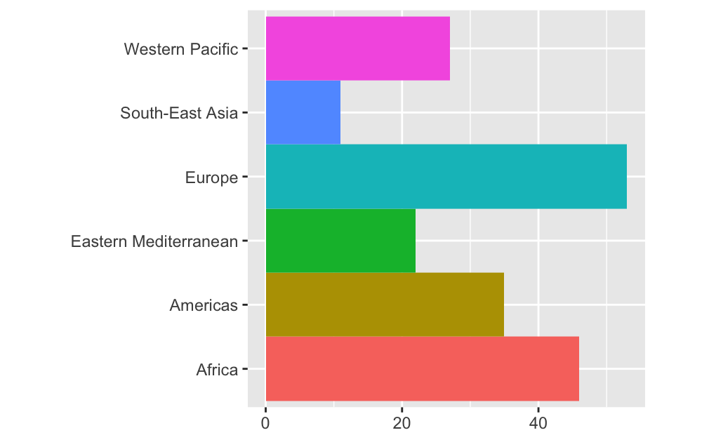

```r
bar <- ggplot(WHO) +
  geom_bar(mapping = aes(x = Region, fill = Region),
           show.legend = FALSE, width = 1) +
  theme(aspect.ratio = 1) +
  labs(x = NULL, y = NULL)
bar + coord_flip()
```

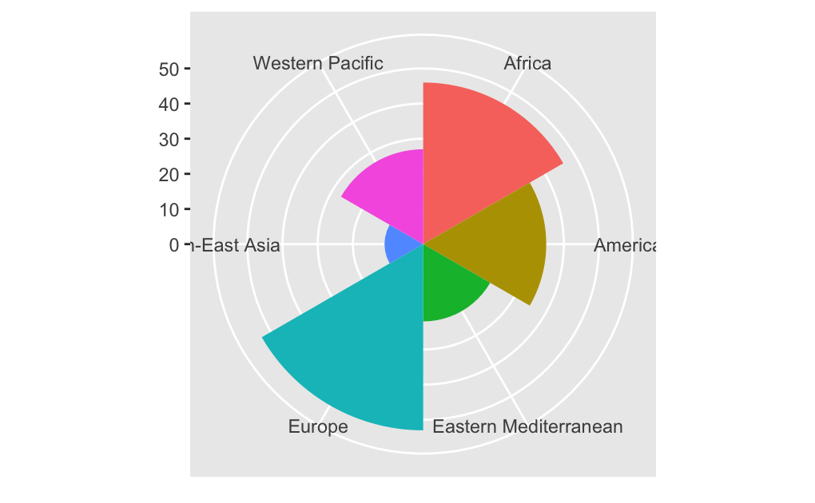

```r
bar + coord_polar()
```

### Scatter plots

Now we compare the following

1. GNI vs Fertility rate
2. GNI vc Literacy Rate
3. GNI vc Life Expectancy

We also subgroup by region sometimes

`facet_wrap` to organise the chart more neatly. Probably should display region with marker color (later), and population size with marker size.

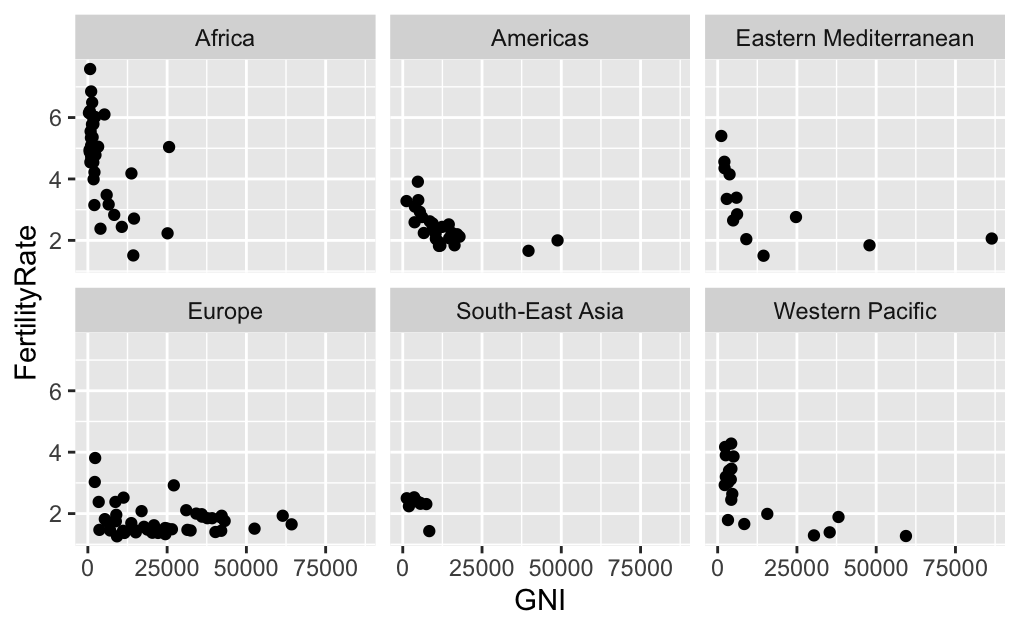

```r
a <- ggplot(WHO, aes(x=GNI, y=FertilityRate))
a + geom_point(na.rm=T) + facet_wrap(.~Region)
```

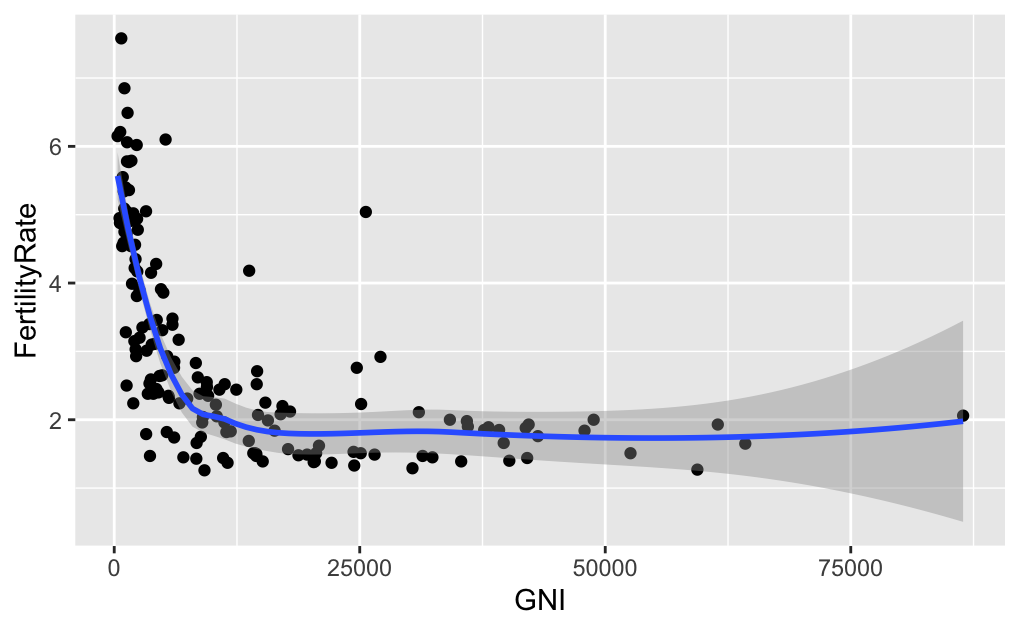

```r
a + geom_point(na.rm=T) + geom_smooth(na.rm=T)
```

Plots a confidence boundary (?) for countries of every region. Messy but we just do it.

(Is there some statistical way to constrain that it is impossible to achieve negative fertility rate?)

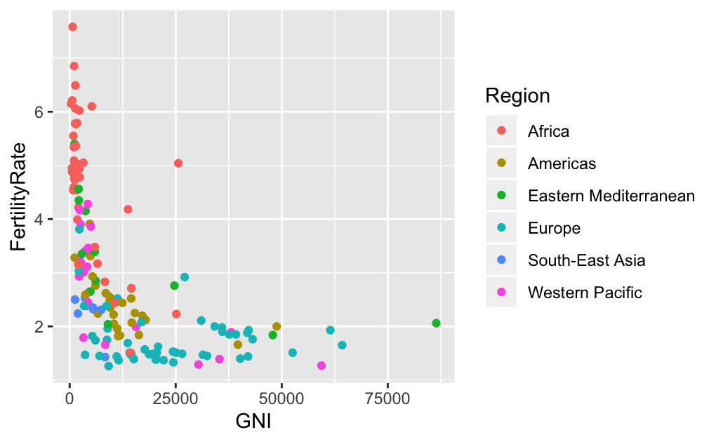

```r
acol <- ggplot(WHO,aes(x=GNI, y=FertilityRate, color=Region))
acol + geom_point(na.rm=T)
```

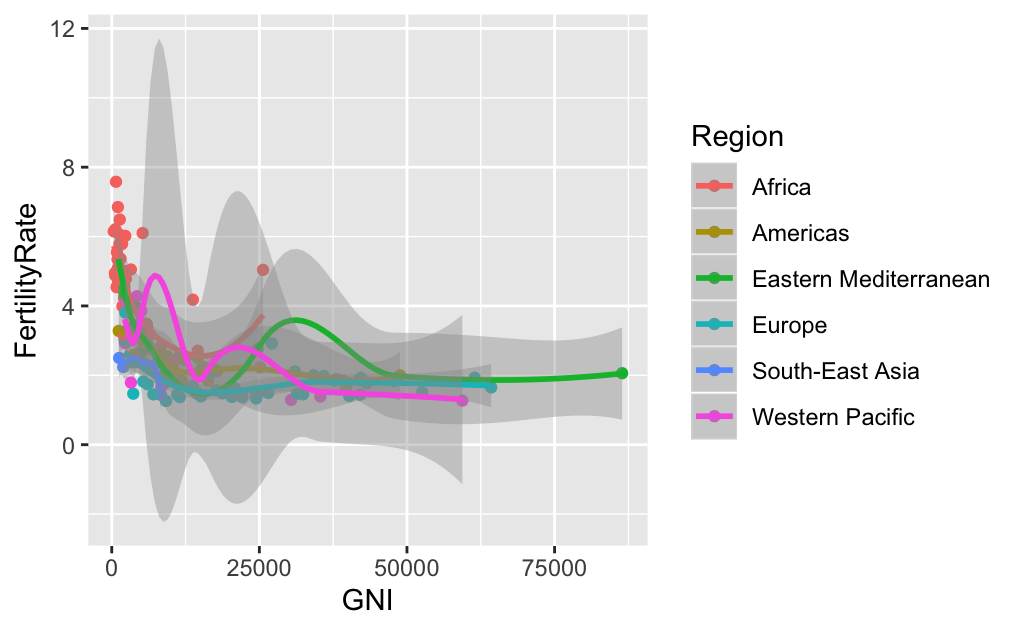

```r
acol + geom_point(na.rm=T) + geom_smooth(na.rm=T)
```